# Simple Linear Regression Analysis

```r
train2 <- train[-which(rownames(train) %in% c(77, 112, 114, 284, 293, 491, 544, 586, 803, 850, 881, 944, 948, 1241, 1325)), ] #iteration 3) remove some outliers based-on Diagnostic Plots
m4_2 <- lm(Price ~ KM_scaled + I(KM_scaled^2) + Age + IfPetrol + Automatic + CC + Weight, data = train2)
summary(m4_2)
```

```
##
## Call:
## lm(formula = Price ~ KM_scaled + I(KM_scaled^2) + Age + IfPetrol +
##     Automatic + CC + Weight, data = train2)
##
## Residuals:
##      Min       1Q   Median       3Q      Max
## -3049.08  -622.34   -28.42   651.23  2799.64
##
## Coefficients:
##                  Estimate Std. Error t value Pr(>|t|)
## (Intercept)    -9276.0561  1577.2443  -5.881 5.73e-09 ***
## KM_scaled       -483.1371    47.6779 -10.133  < 2e-16 ***
## I(KM_scaled^2)   -39.3231    21.3833  -1.839  0.06625 .
## Age             -101.9608     2.6861 -37.958  < 2e-16 ***
## IfPetrolTRUE    1240.6317   165.2443   7.508 1.44e-13 ***
## Automatic1        78.2456   144.2782   0.542  0.58773
## CC                -0.8342     0.3059  -2.727  0.00652 **
## Weight            23.9596     1.5862  15.105  < 2e-16 ***
## ---
## Signif. codes:  0 '***' 0.001 '**' 0.01 '*' 0.05 '.' 0.1 ' ' 1
##
## Residual standard error: 939.6 on 904 degrees of freedom
## Multiple R-squared:  0.8382, Adjusted R-squared:  0.837
## F-statistic: 669.1 on 7 and 904 DF,  p-value: < 2.2e-16
```

> **Automatic1** is not significant (has high p-value)

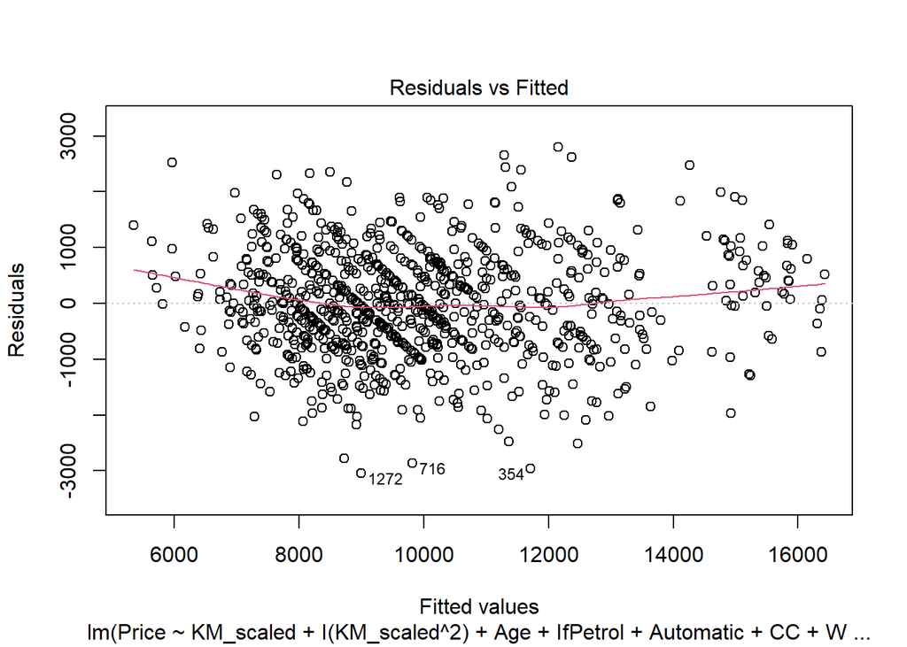

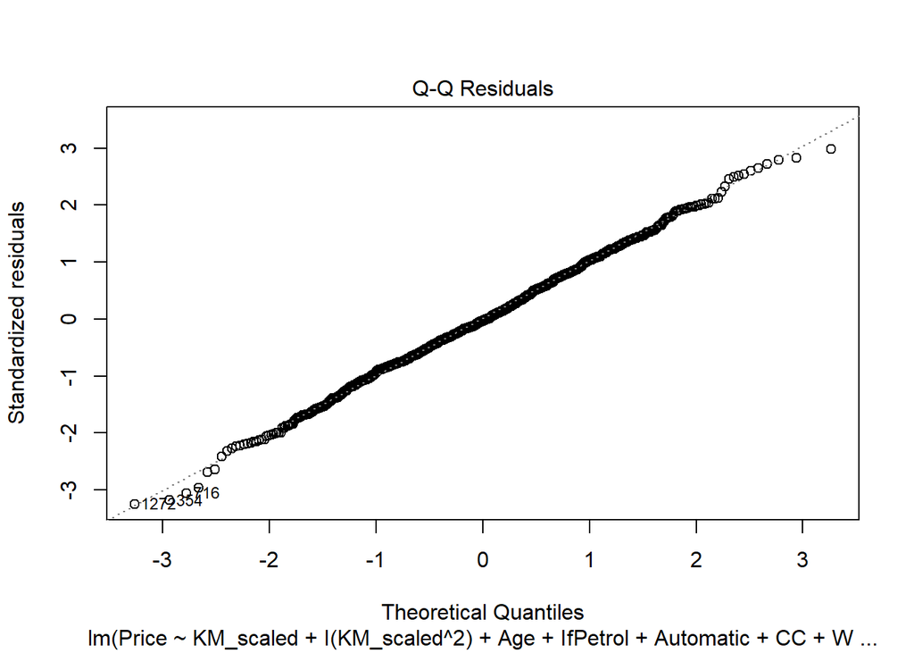

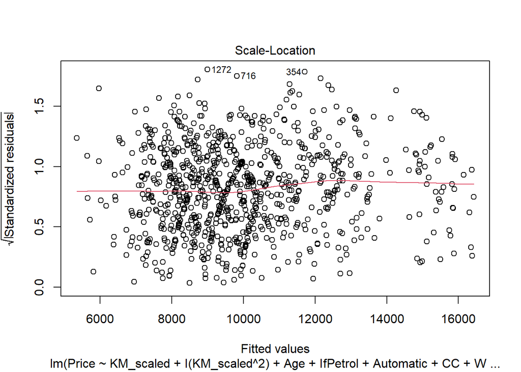

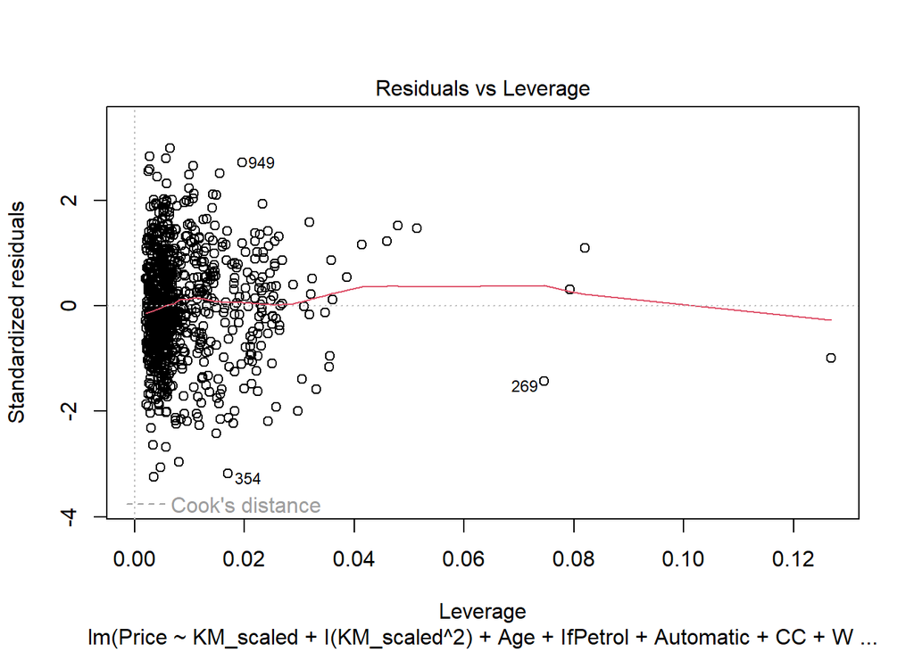

```r
plot(m4_2)
```

## 6.8 Model 4_3: remove Automatic

```r
m4_3 <- lm(Price ~ KM_scaled + I(KM_scaled^2) + Age + CC + IfPetrol + Weight, data = train2)
summary(m4_3)
```

```
##
## Call:
## lm(formula = Price ~ KM_scaled + I(KM_scaled^2) + Age + CC +
##     IfPetrol + Weight, data = train2)
##
## Residuals:
##      Min       1Q   Median       3Q      Max
## -3053.17  -628.20   -31.04   647.44  2800.02
##
## Coefficients:
##                  Estimate Std. Error t value Pr(>|t|)
## (Intercept)    -9506.1065  1518.5387  -6.260 5.94e-10 ***
## KM_scaled       -485.9211    47.3823 -10.255  < 2e-16 ***
## I(KM_scaled^2)   -38.8982    21.3606  -1.821  0.06893 .
## Age             -101.6617     2.6279 -38.685  < 2e-16 ***
## CC                -0.8675     0.2996  -2.896  0.00388 **
## IfPetrolTRUE    1245.6000   164.9258   7.552 1.04e-13 ***
## Weight            24.2074     1.5183  15.943  < 2e-16 ***
## ---
## Signif. codes:  0 '***' 0.001 '**' 0.01 '*' 0.05 '.' 0.1 ' ' 1
##
## Residual standard error: 939.3 on 905 degrees of freedom
## Multiple R-squared:  0.8382, Adjusted R-squared:  0.8371
## F-statistic: 781.2 on 6 and 905 DF,  p-value: < 2.2e-16
```

Normality of residuals (Check Normality Assumption)

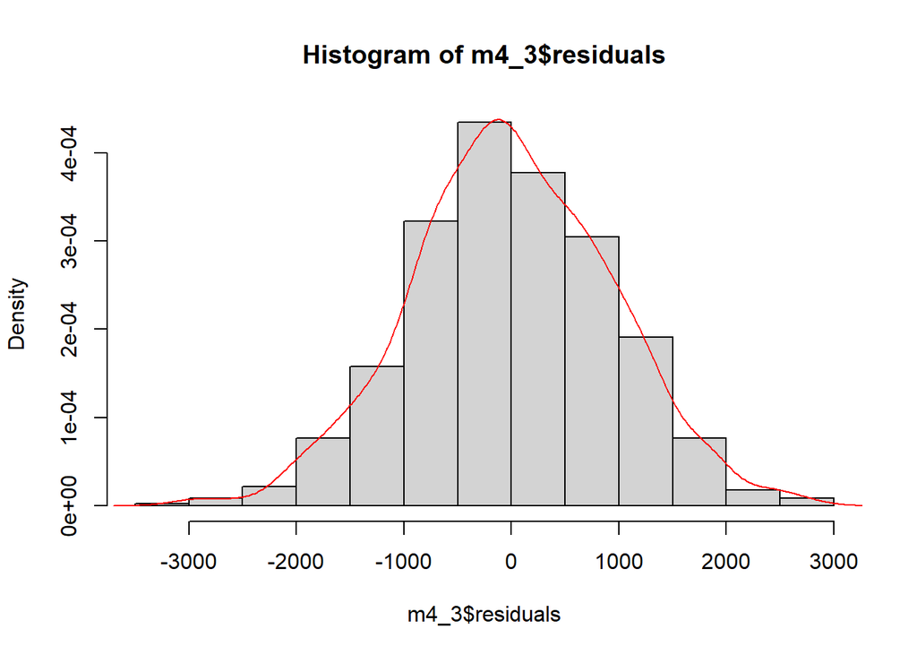

```r
hist(m4_3$residuals, breaks = 20, freq = F)
lines(density(m4_3$residuals), col = 'red')
```

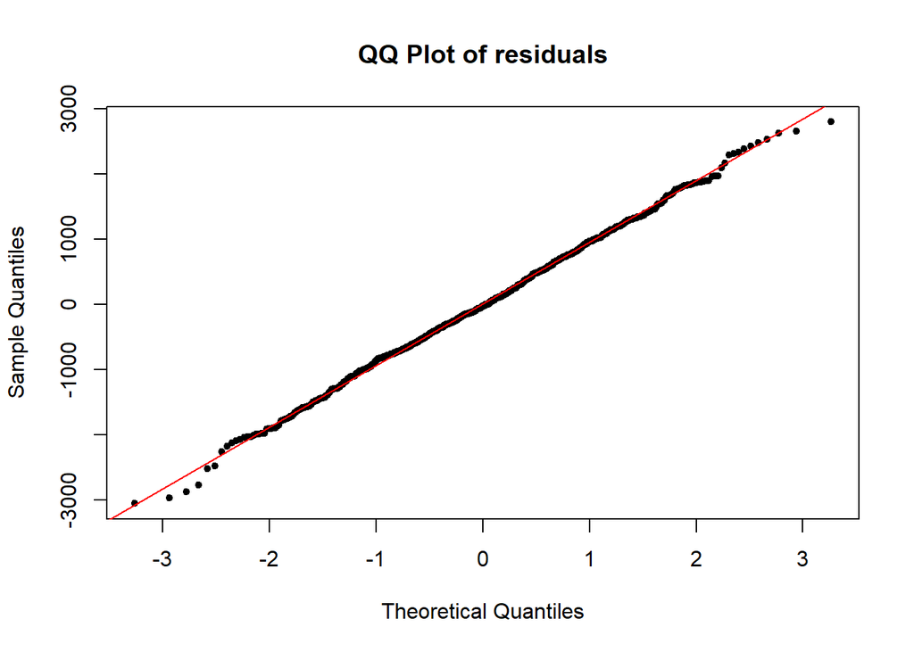

```r
qqnorm(m4_3$residuals, main='QQ Plot of residuals', pch = 20)
qqline(m4_3$residuals, col='red')
```

```r
#p-value < 0.05 reject normality assumption
jarque.test(m4_3$residuals)
```

```
##
##  Jarque-Bera Normality Test
##
## data:  m4_3$residuals
## JB = 0.2012, p-value = 0.9043
## alternative hypothesis: greater
```

```r
#p-value < 0.05 reject normality assumption
anscombe.test(m4_3$residuals)
```

```
##
##  Anscombe-Glynn kurtosis test
##
## data:  m4_3$residuals
## kurt = 3.06777, z = 0.52823, p-value = 0.5973
## alternative hypothesis: kurtosis is not equal to 3
```

> **result**: residuals are Normal

Diagnostic plots

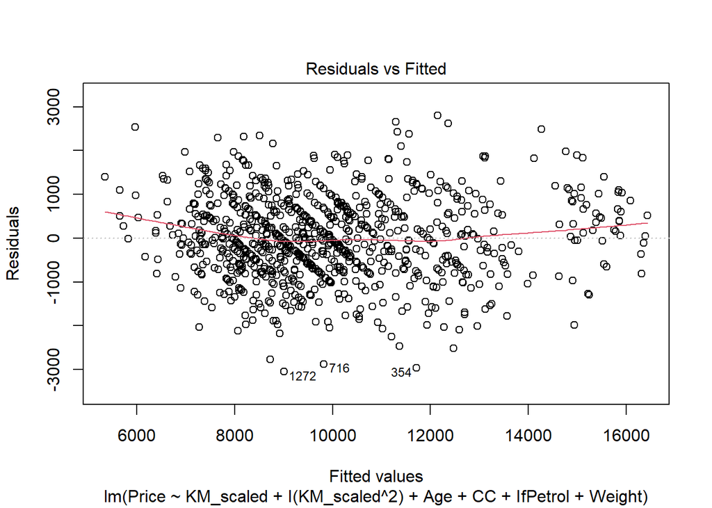

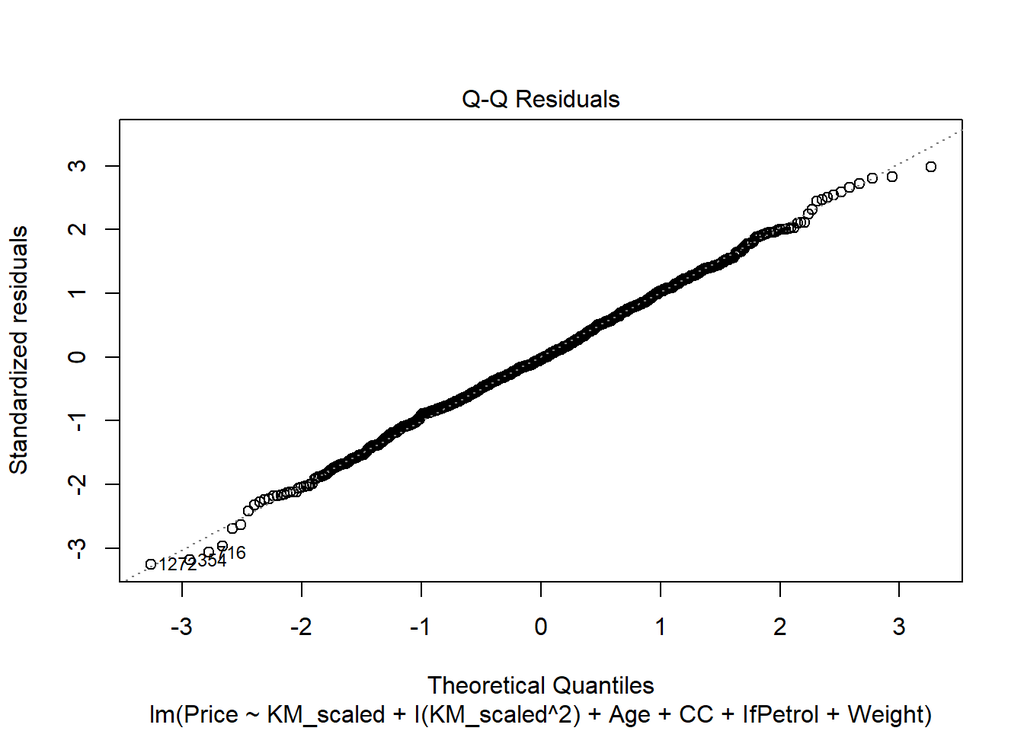

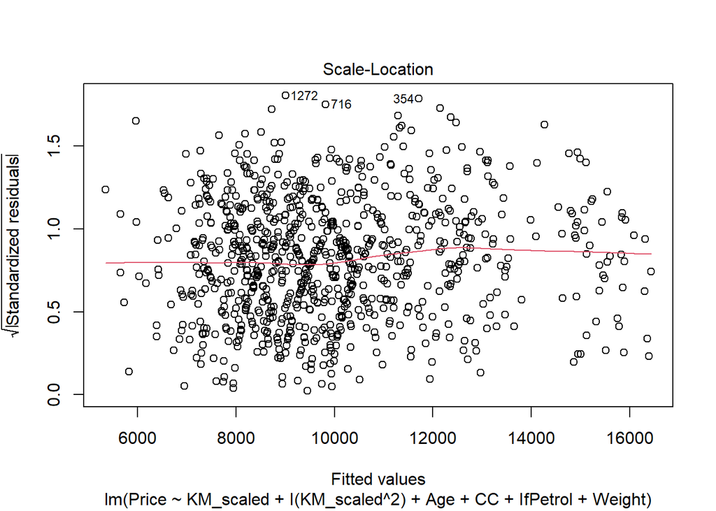

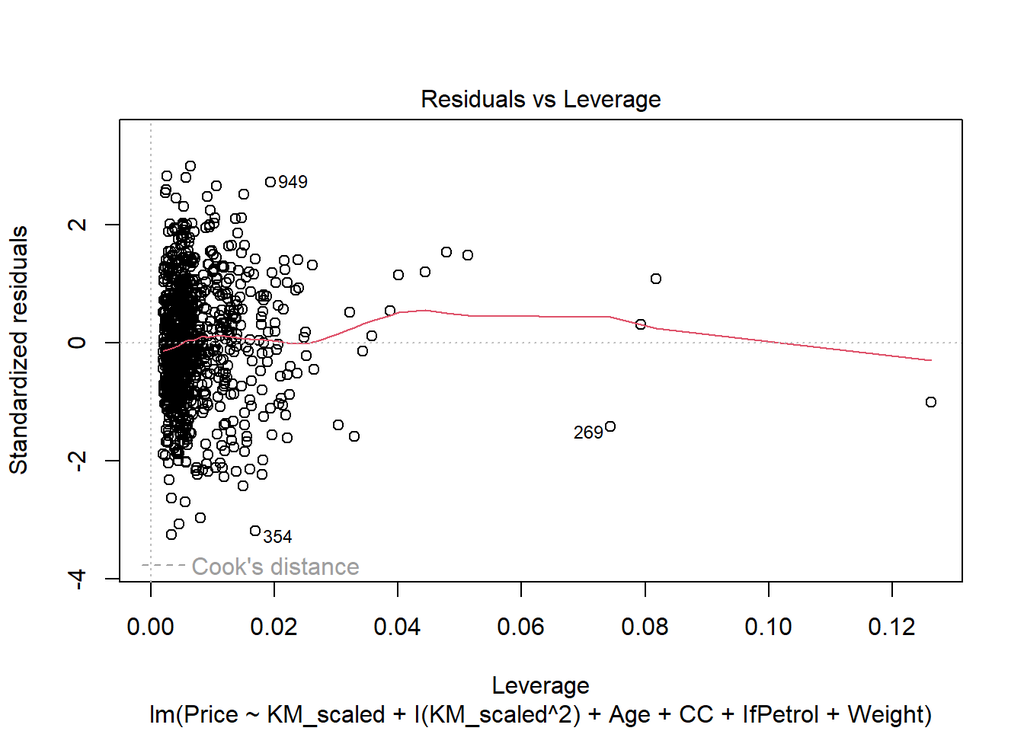

```r
plot(m4_3)  # all are good
```

Check Multicollinearity

```r
car::vif(m4_3)  # have no value over 10 (or over 5) -> there isn't Mulitcollinearity problem
```

```
##      KM_scaled I(KM_scaled^2)            Age             CC       IfPetrol
##       2.218818       1.616775       1.652790       3.149170       2.672516
##         Weight
##       3.028240
```

Compare Two models

```r
coef(m4)  # model with outliers
```

```
##    (Intercept)      KM_scaled I(KM_scaled^2)            Age   IfPetrolTRUE
##   4862.1130205   -415.3329625    -48.8230719   -113.9792270   1062.5471644
##     Automatic1             CC         Weight
##    452.4074492      0.9938987      8.7821504
```

```r
coef(m4_3)  # model without outliers
```

```
##    (Intercept)      KM_scaled I(KM_scaled^2)            Age             CC
##   -9506.106455    -485.921106     -38.898229    -101.661708      -0.867481
##   IfPetrolTRUE         Weight
##    1245.600042      24.207432
```

Number of removed cases:

```r
dim(train)
```

```
## [1] 927  12
```

```r
dim(train2)
```

```
## [1] 912  12
```

```r
nrow(train)-nrow(train2)  # 15 Observations
```

```
## [1] 15
```

```r
(nrow(train)-nrow(train2))/nrow(train)*100  # 1.6% of observations is removed
```

```
## [1] 1.618123
```

# 7 Model Evaluation

## 7.1 Test the Model 4_3 performance

Data Preparation

```r
head(test)
```

|  | Price | Age | KM | FuelType | HP | MetColor | Automatic | CC | Doors | Weight |
| --- | --- | --- | --- | --- | --- | --- | --- | --- | --- | --- |
| 1 | 13500 | 23 | 46986 | Diesel | 90 | 1 | 0 | 2000 | 3 | 1165 |
| 5 | 13750 | 30 | 38500 | Diesel | 90 | 0 | 0 | 2000 | 3 | 1170 |
| 8 | 12950 | 23 | 71138 | Diesel | 69 | 0 | 0 | 1900 | 3 | 1105 |
| 10 | 16950 | 30 | 64359 | Petrol | 110 | 1 | 0 | 1600 | 3 | 1105 |
| 18 | 16950 | 28 | 44142 | Petrol | 110 | 0 | 0 | 1600 | 3 | 1120 |
| 27 | 15750 | 32 | 25329 | Petrol | 97 | 1 | 0 | 1400 | 3 | 1100 |

```r
test$KM_scaled <- scale(test$KM)
test$IfPetrol <- ifelse(test$FuelType == 'Petrol', T, F)
head(test)
```

|  | Price | Age | KM | FuelType | HP | MetColor | Automatic | CC | Doors | Weight | KM_scaled | IfPetrol |
| --- | --- | --- | --- | --- | --- | --- | --- | --- | --- | --- | --- | --- |
| 1 | 13500 | 23 | 46986 | Diesel | 90 | 1 | 0 | 2000 | 3 | 1165 | -0.65051899 | FALSE |
| 5 | 13750 | 30 | 38500 | Diesel | 90 | 0 | 0 | 2000 | 3 | 1170 | -0.88312634 | FALSE |
| 8 | 12950 | 23 | 71138 | Diesel | 69 | 0 | 0 | 1900 | 3 | 1105 | 0.01150465 | FALSE |
| 10 | 16950 | 30 | 64359 | Petrol | 110 | 1 | 0 | 1600 | 3 | 1105 | -0.17431260 | TRUE |
| 18 | 16950 | 28 | 44142 | Petrol | 110 | 0 | 0 | 1600 | 3 | 1120 | -0.72847507 | TRUE |
| 27 | 15750 | 32 | 25329 | Petrol | 97 | 1 | 0 | 1400 | 3 | 1100 | -1.24415290 | TRUE |

```r
dim(test)
```

```
## [1] 398  12
```

Prediction

```r
test$pred <- predict(m4_3, test)  # input test data into m4_3 model (use model m4_3 to predict Price on Test dataset)
head(test)
```

|  | Price | Age | KM | FuelType | HP | MetColor | Automatic | CC | Doors | Weight | KM_scaled | IfPetrol | pred |
| --- | --- | --- | --- | --- | --- | --- | --- | --- | --- | --- | --- | --- | --- |
| 1 | 13500 | 23 | 46986 | Diesel | 90 | 1 | 0 | 2000 | 3 | 1165 | -0.65051899 | FALSE | 14922.01 |
| 5 | 13750 | 30 | 38500 | Diesel | 90 | 0 | 0 | 2000 | 3 | 1170 | -0.88312634 | FALSE | 14430.57 |
| 8 | 12950 | 23 | 71138 | Diesel | 69 | 0 | 0 | 1900 | 3 | 1105 | 0.01150465 | FALSE | 13251.08 |
| 10 | 16950 | 30 | 64359 | Petrol | 110 | 1 | 0 | 1600 | 3 | 1105 | -0.17431260 | TRUE | 14134.41 |
| 18 | 16950 | 28 | 44142 | Petrol | 110 | 0 | 0 | 1600 | 3 | 1120 | -0.72847507 | TRUE | 14950.66 |
| 27 | 15750 | 32 | 25329 | Petrol | 97 | 1 | 0 | 1400 | 3 | 1100 | -1.24415290 | TRUE | 14444.37 |

## 7.2 Evaluate model performance in Test dataset:

Actual vs. Prediction

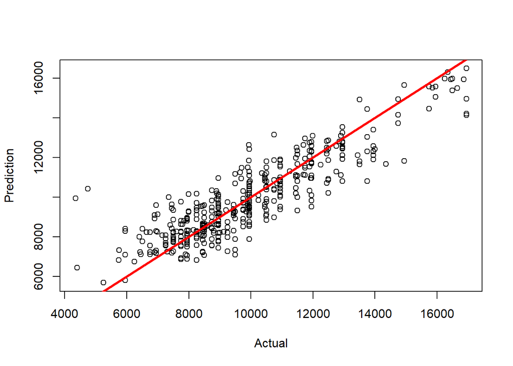

```r
plot(x = test$Price, y = test$pred, xlab = 'Actual', ylab = 'Prediction')
abline(a = 0, b = 1, col = 'red', lwd = 3)  # compare with 45' line
```

Absolute Error mean, median, sd, max, min

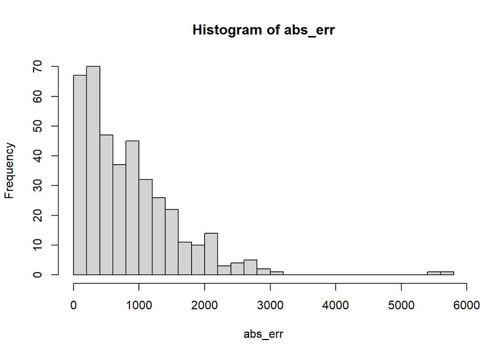

```r
abs_err <- abs(test$Price - test$pred) #absolute value (AEV)

hist(abs_err, breaks = 25)  # residuals distribution
```

```r
mean(abs_err)
```

```
## [1] 843.1747
```

```r
median(abs_err)
```

```
## [1] 666.9668
```

```r
sd(abs_err)
```

```
## [1] 737.0546
```

```r
max(abs_err)
```

```
## [1] 5665.839
```

```r
min(abs_err)
```

```
## [1] 0.5225591
```

Boxplot (which observations are outliers?)

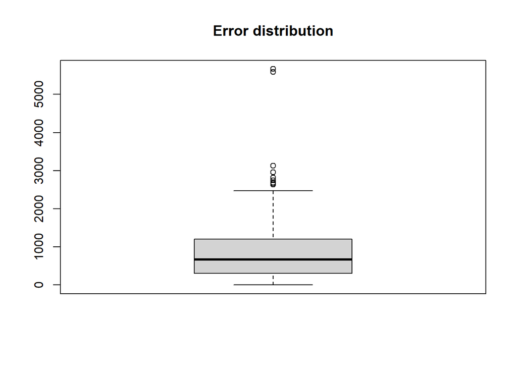

```r
boxplot(abs_err, main = 'Error distribution')
```

Error Percentage median, sd, mean, max, min

```r
e_percent <- abs(test$Price - test$pred)/test$Price * 100
summary(e_percent)
```

```
##      Min.   1st Qu.    Median      Mean   3rd Qu.      Max.
##   0.00498   3.00949   6.80038   9.22719  12.66761 128.47065
```

```r
sum(e_percent <= 15)/length(e_percent)*100  # 84.17% of predicted prices fall between [-15%, +15%] actual price
```

```
## [1] 84.17085
```

> **Conclusion**: we created a robust model

For more information check the [Github](https://github.com/mamomen1996/R_CS_03) repository.